# Statistical Models

Statistical Learning - Week 3

Julie Bessac

2026

# Models

## Why Models?

**“All models are wrong, but some are useful.” — George Box**

Remember, we said that data are a materialization of underlying process and are not ground truth.

We have similar insights about statistical models,  
**Key idea:** Models are *simplifications*, not mirrors of reality.

Their value comes from insight, prediction, and decision-making—not perfection.

## Learning Goals

By the end of this module, you should be able to:

- Explain *why* randomness is essential in data models
- Write the generic form of a statistical learning model
- Distinguish **linear vs nonlinear** models (correctly!)
- Recognize common modeling assumptions—and when they fail
- Fit and interpret basic models in **R**

## Deterministic vs Stochastic Thinking

### A Deterministic (Mathematical) Model

**Example:** pollutant concentration in a river
$$\alpha(s,t) = \alpha_0(s-ct)\exp(-\mu
t)$$

- Inputs → Output, no uncertainty, no room for chance
- Same inputs → same output, every time
- Assumes *perfect knowledge* of the system
- Predicts with certainty

**Reality check:** rivers, sensors, and environments are messy and complex.

### Why Determinism Fails in Practice

Hidden assumptions made in deterministic modeling:

- Perfect measurements
- Perfect mixing
- No turbulence or local effects
- Constant decay rates in space and time

**Question:** Can we *ever* measure and control all of this?

In reality:

- Measurements are made in a highly dynamic environment (river)
- How can we account for all influences in the environment?
- How can we account for sampling the environment?

## Adding Randomness (On Purpose)

We upgrade the model by admitting uncertainty:
$$\alpha(s,t) = \alpha_0(s-ct)\exp(-\mu t) +
\epsilon$$
$\epsilon$: random error, mean 0, variance $\sigma^2$
Often assume: $\epsilon \sim N(0,\sigma^2)$

- **Interpretation:**
  Individual observations vary
  The *average behavior* follows the deterministic exponential model
  $$\mbox{E}[\alpha(s,t)] =
  \alpha_{0}(s−ct) \exp {−\mu t}$$
- **Consequence:** Because $\epsilon$ is random, so is $\alpha(s,t)$ (randomness is contagious)
- Can you think of an extension model for $\epsilon$?

## “Correct on Average”

- The model is *not* exact for every single observation
- It *is* correct **in expectation**

**Think about the consequences and differences for:**

- Predicting *your* credit score vs
- Estimating the *average* credit score of people like you

## Why Randomness is Essential

Randomness helps us:

- Model unobserved or unmeasurable influences
- Justify random sampling and experiments
- Build simpler, more interpretable models
- Overcome parts of unpredictablity and unknown components

**Occam’s Razor:**

- Among competing explanations prefer the simpler
- Stochastic models are often more *parsimonious* (fewer parameters) and easier to explain
- They often explain more with less.

## Parsimony Example

- **Goal:** develop a model to predict cardiovascular disease occurrence (yes/no)
- **Reality:** dozens of biological conditions (family history), clinical (other pathologies, age, sex), and lifestyle factors (nutrition, sedentarity)
- **Start simple:**
  - Let $Y \in \{0,1\}$, the diseases occurs or not
  - $Y \sim \text{Bernoulli}(\pi)$
    $$\Pr(Y=1)=\pi, \quad
    \Pr(Y=0)=1-\pi$$
- In this case, we need to estimate $\pi$ on the data to make the model usable and matching our data.
- If we have a random sample of patients with 0/1 disease outputs, then the sample mean is possible estimator:
  $$\widehat{\pi} = \frac{1}{n}\sum_{i=1}^n
  Y_i,$$

## Statistical Models

A **statistical model** is a stochastic model with **unknown parameters**

**Unknown parameters** are estimated on available data

Going back to the above example:

- $\pi$: event probability (parameter to be estimated)
- Data → estimate parameters $\widehat{\pi} = \frac{1}{n}\sum_{i=1}^n Y_i,$

**Key idea:**

- If Y is random, every function of Y is random (randomness is contagious)  
  → $\widehat{\pi}$ is a random variable
- Parameter estimates are random variables with their own distributional properties
- We chose parameter estimates with satisfactory properties (see Estimation ch.)

## Why Statistical Learning?

- This Bernoulli model is a possible model for disease recurrence, but too simplistic
- In the above model, $\widehat{\pi}$ is solely derived from the 0/1 disease outputs,  
  but does not account for other obvious factors (age, sex, family history)
- Other factors are less obvious
- Express $\pi$ as a function of other inputs and parameters
  $$\pi = f
  (x_1,x_2,···,x_p; \theta_0, \theta_1,
  \theta_2,...\theta_p)$$

We build models to:

### Explain

- How do inputs affect outputs? What is the input-output relationship?
- Which input variables matter?
- What functional relationships are plausible?

### Predict

- Estimate/predict unseen outcomes
- Generalize to new data

Often: **we want both**.

## When Prediction Matters Most

Prediction is crucial when outcomes are:

- **Destructive** (stress testing materials)
- **Expensive** (medical tests)
- **Rare** (fraud detection)
- **In the future** (stock prices, demand)

## The Basic Model Template

Most (*not all*) statistical learning models look like:

**Response = Structure + Error**

$$Y =
f(x_1,\ldots,x_p;\theta_0,\theta_1,\ldots,\theta_k) +
\epsilon$$

- **Y: Response**: what we care about  
  Other names are output, outcome, target, dependent variable  
  Upper-case Y when referring to the random variable  
  Lower-case y is the observed value
- **Structure**: systematic part of the model (mean function)  
  It expresses the expected value (the mean) of the response as a function of inputs and parameters and is therefore also called the mean function
  - $x_1,...,x_p$: the inputs, a.k.a. regressors, explanatory variables, features, independent variables
  - $f$ functional form between input and output  
    E.g. linear regression, polynomial regression
  - $\theta_0,\theta_1,\ldots,\theta_k$: the parameters to be estimated from the data
- **$\epsilon$: Error**: the random component(s) (inherent stochasticity, unpredictability,…)  
  $\epsilon$ the model error; assumed that $\epsilon$ has mean $0$ and variance $\sigma^2$ Defines the distributional properties of the response

## Observational Model

In practice, we will have access to a finite set of observations for the problem at stake,

The observational model introduces an index for the $n$ observations:
$$Y_i = f(x_{1i},x_{2i},\ldots,x_{pi},
\theta_0,\theta_1,\ldots,\theta_k) + \epsilon_i, \qquad i=1,\cdots,
n$$

- $Y_1, Y_2, \ldots, Y_n$ are the sample of size $n$  
  The $Y_i$ are random variables
- $y_1, y_2, \ldots, y_n$ are the observed values, e.g., $12.4$, $5.7$, , $9.4$  
  The $y_i$ are *not* random variables, but their realizations
- The inputs $x_{1i}, \ldots, x_{pi}$ are typically *not* random variables  
  Inputs treated as *given* (conditional modeling)
- We will see in the Estimation class how to arrange these observations

## Example: Mitscherlich Equation

The Mitscherlich model is used in plant studies to express growth (yield) as a function of an input (fertilizer).
$$\mbox{Abstract form (response/structure/error)}
\quad Y = f(x,\xi,\lambda,\kappa) + \epsilon,$$
$$\mbox{Specific formulation} \quad Y = \lambda +
(\xi - \lambda)\exp\left\{-\kappa x\right \} + \epsilon$$

- $Y$ is the yield
- $x$ is the amount of input, e.g., nitrogen fertilizer

Always take some time to understand the parameters of your model:

- $\lambda$ is …
- $\xi$ is …
- $\kappa$ is …
- $\epsilon \sim (0,\sigma^2)$

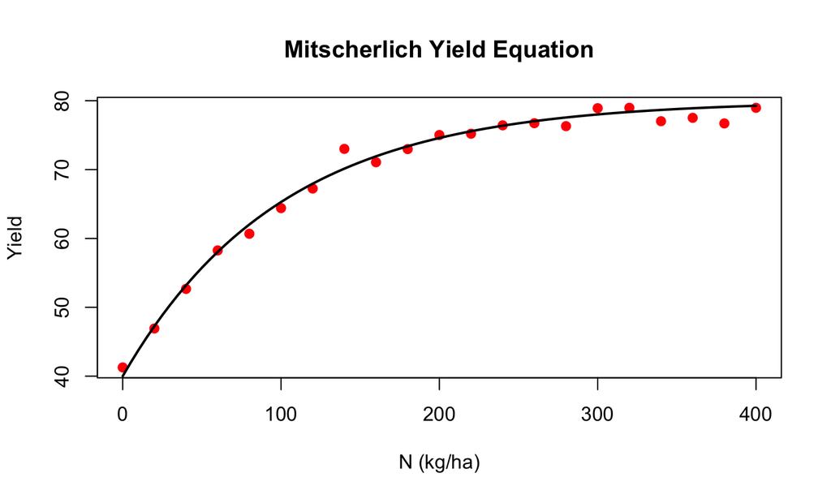

Mitscherlich Equation

Can you ``estimate’’ the $\lambda, \xi$, and $\kappa$ parameters visually?

How would you fit such a model on a dataset?

## Prediction & Explanation

**Explanatory inference**, also called confirmatory inference, is concerned with

- understanding the relationship between response and inputs
- understanding the importance of the inputs
- testing hypotheses about the response
- ISLR calls this ``Inference’’ in Sec. 2.1

**Predictive** inference is concerned with

- developing an algorithm that predicts the outcome well
- generalizing the algorithm to new observations (not measured, not yet seen, etc.)

**Mitscherlich Example**

Many applications have predictive and confirmatory goals

*Predictive Insights*

- Provide a confidence interval for the average yield at $x_{new}=35.7$ kg/ha
- At what level of nitrogen does yield achieve 75% of the max (=inverse prediction).

*Confirmatory Insights*

- The asymptotic yield is greater than 75
- Increasing nitrogen application raises the yield by no more than 30 units
- The rate of change in yield is less than $p$ units per unit nitrogen once 100 $kg/ha$ x are applied.

**Confirmatory Insights**

- Good confirmatory models are not necessarily best at prediction
- Parameter interpretation is very important
- Hypotheses are expressed in terms of parameters and their relationships

**Predictive Insights**

- Models that predict well are not necessarily best at testing hypotheses
- Parameter interpretation is less important
- A model that is biased can be more desirable than an unbiased model

Many disciplines place high value on interpretability of the models.  
Sometimes, prediction is used as a validation rather than an end goal.

For example,

- Biology
- Life sciences
- Economics
- Financial Services & Insurance
- Physical sciences
- Geosciences

# Classes of Models

## Linear vs Nonlinear Models

**Linear ≠ straight line**

A model is **linear** if it is linear in its *parameters*

Nonlinearity does not refer to curvature of the mean function

A model is **nonlinear** if at least one derivative of the mean function wrt the parameters depends on one or more parameters

- Mitscherlich Example
  $$f(N,
  \xi,\lambda,\kappa) = \lambda + (\xi - \lambda)\exp\left\{ -\kappa N
  \right \}$$
  $$\frac{\partial
  f(N,\xi,\lambda,\kappa)}{\partial \lambda} = 1 -\exp\left\{ -\kappa N
  \right \}$$
- the model is nonlinear

Are the following models linear or nonlinear? Response: $Y$ ; Predictor: $x$, $x_1$, $x_2$

**Model 1:** $E[Y] = \beta_0 + \beta_1 x_1 + \beta_2 x_2$  
$\rightarrow$ Multiple linear regression

**Model 2:**  
$E[Y] = \left \{ \begin{array}{ll} \beta_0 + \beta_1 x & x \leq \alpha \\ \beta_0 + \beta_1\alpha & x > \alpha \end{array} \right.$  
$\rightarrow$ Plateau (hockey-stick) model is non-linear

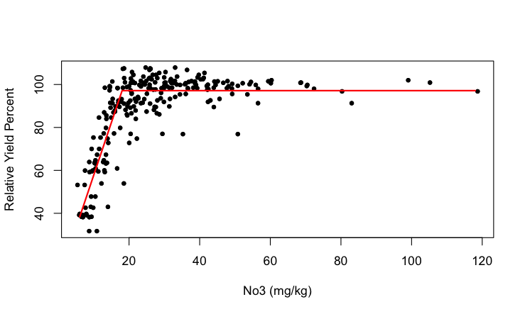

Example of a plateau model

**Model 3:** $E[Y] = Y = \beta_0 + \beta_1 x^2 + \beta_2 x^2 + \beta_3 x^3$  
$\rightarrow$ Polynomial regression (nonlinear shape, linear model)

## Linear Models (Regression Example)

**Regression:** the inputs are (continuous) numeric variables
$$Y_i = \beta_0 + \beta_1 x_{1i} +
\cdots + \beta_p x_{pi} + \epsilon_i$$
with $\epsilon_i$ i.i.d. (independent and identically distributed)
and $\epsilon \sim (0, \sigma^2)$

**Simple linear regression:** $Y_i = \beta_0 + \beta_1 x_{1i} + \epsilon_i$

**Multiple linear regression:** more than one input (regressor variable)

## Linear Models Components

**Linear Regression Example**

*Components*

- The $\beta$ are the $p+1$ parameters of the mean function **to be estimated**
- $\beta_0$ is called the *intercept*
- $p$ = number of inputs
- $\sigma^2$, the error variance is also a parameter **to be estimated**

*Interpretation*

- $\beta_0$ is the mean of $Y$ when $x_1 = 0, \cdots, x_k = 0$
- $\beta_j$ is the change in the mean of $Y$ when $x_j$ increases by 1 unit and all other $x$s do not change
- Example $\beta_3 = 4.2$: If $x_3$ increases by 1 unit, $\text{E}[Y]$ increases by 4.2 units

## Linear Models Assumptions

**Linear Regression Example**

- The inputs $x_{1i}, \cdots , x_{pi}$ are fixed, not random
- The errors $\epsilon_i$ have zero mean (model is correct on average)
- The errors $\epsilon_i$ have equal variance (homoscedasticity)
- The errors $\epsilon_i$ are independent
- Because $\epsilon_i$ has mean (=expected value) $0$, it follows that $\begin{array}{ll} \text{E}[Y_i] &= \text{E} \left[\beta_0 + \beta_1 x_{1i} + \cdots + \beta_p x_{pi} + \epsilon_i \right]\\ &= \beta_0 + \beta_1 x_{1i} + \cdots + \beta_p x_{pi} + \text{E}[\epsilon_i] \\ &= \beta_0 + \beta_1 x_{1i} + \cdots + \beta_p x_{pi} \end{array}$
- Because $\beta_0+\beta_1 x_{1i}+\cdots+\beta_p x_{pi}$ is the expected value (=the mean) of $Y_i$,  
  it is also called the **mean function**.  
  It is implicit in this derivation that the inputs $x$ are not random.

**Conditioning Saves Us**

“X is not random” really means:

We model **Y given X = x**

$$(Y\mid X=x) = \beta_0 + \beta_1 x +
\epsilon$$
Conditioning turns observed inputs into constants.

- Describe situations when the assumptions of the linear model are not met,
- Is normality of the errors an assumption of the linear model?

Assuming we want to predict the abalone height, which assumptions of linear regressions are violated in the following relationships?

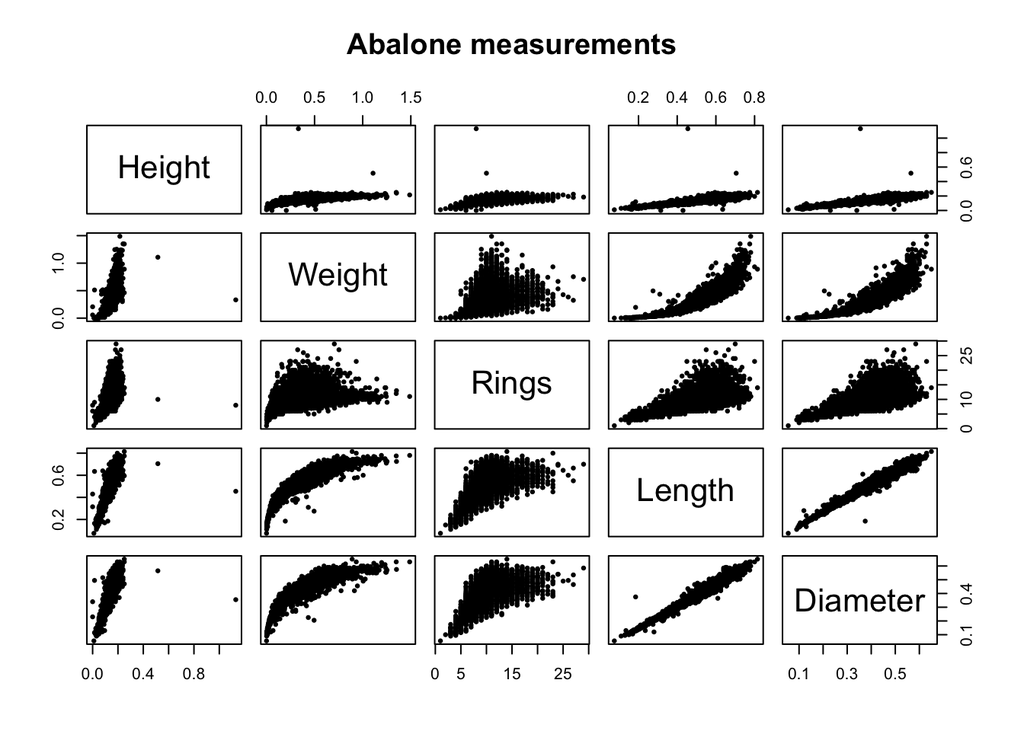

## Linear Models

- Many models contain both continuous and qualitative inputs.
- Take advantage of qualitative inputs to build interesting models and address interesting questions
- Suppose a qualitative variable segments the data into groups  
  (e.g. genders, age groups, income classes, tax brackets, …)  
  Do groups share the same basic model?  
  Do slopes and/or intercepts differ between groups?  
  Is there an interaction between groups and continuous inputs?
- Let’s work with the abalone data

In `R`, it is easy to implement interactions between predictors (continuous and-or categorical).

Using the function `lm`:

- `lm(Y ~ X + Z + X:Z)` includes each of the predictors individually (the main effects) and their interaction (`:` accounts for the interaction only).
- `lm(Y ~ X*Z)` is the compact way of writing `lm(Y ~ X + Z + X:Z)`
- When one predictor is continuous and the other categorical, these interaction terms have the following meaning:  
  Assume `X` is continuous and `Z` has two categories,  
  `lm(Y ~ X)` fits the same intercept and slope for both categories,  
  `lm(Y ~ X+Z)` fits the same slope for both categories but different intercept,  
  `lm(Y ~ X:Z)` fits the same intercept but different slope per category,  
  `lm(Y ~ X*Z)` fits different intercept and slope per category.

**This is model comparison**, not just fitting.

*Think about the abalone data when we predict the height from diameter and sex*

## Nonlinear Regression (Reality Bites)

**Remember:**

- A non-linear model depends on its parameters in a non-linear fashion,
- A model is **nonlinear** if at least one derivative of the mean function wrt the parameters depends on one or more parameters

Nonlinear models are more finicky to work with than linear models:

- Finding parameter estimates is done through iterative numerical optimization
- Providing good starting values for the parameter helps greatly
- Good software computes analytic derivatives rather than finite difference derivatives
- Statistical properties of estimators are not as clear cut as with linear models

We can still use least-squares to fit such models

Typically, in `R` we use `nls` or the library `nls2`

Example: Plateau model  
You specify the mean function as the first argument of `nls` or pass an object with the formula for the mean function.

```r
plat_model <- y ~ (b0+b1*x    )*(x <= alpha) +
                  (b0+b1*alpha)*(x >  alpha)

plat_fit <- nls(plat_model,
                data=whatever,
                start=list(b0=0,b1=5,alpha=40))
```

## Non-parametric Regression

Non-parametric regression refers to a family of regression methods where you don’t assume a fixed functional form (like linear, quadratic, etc.) between predictors $X$ and response $Y$

Instead of $Y = \beta_0 + \beta_1 X + \epsilon$, you have $Y=f(X) + \epsilon$.

**Key characteristics**

- No predefined model form for $f$  
  Predictors completely constructed using information derived from the data
- Model complexity grows with sample size
- Usually local or smooth fits
- Sensitive to:
  - sample size
  - smoothing parameters (bandwidth, number of neighbors, tree depth, etc.)

## Non-parametric Regression Examples

1. k-Nearest Neighbors (kNN) regression
   - Predict by averaging nearby points, very intuitive
   - Curse of dimensionality hits hard
2. Kernel regression (Nadaraya–Watson)
   - Predict by smoothing weighted average
   - Bandwidth $h$ controls bias–variance tradeoff
3. Local polynomial regression (LOESS / LOWESS)
   - Fit a small regression locally around each $x$
4. Regression trees
   - Partition feature space into regions
   - Basis for Random Forests and Boosting
5. Splines and smoothing splines
   - f(x) is a sum of smooth (splines) basis functions

We will review these models and their implementations in more details in future classes.

## Parametric vs Nonparametric

### Parametric

*few parameters, strong assumptions, rigid shape*

- Explicit expression for the mean function in terms of inputs and parameters
- Linear regression model: $Y = \beta_0 + \beta_1 x_1 + ... + \beta_p x_p + \epsilon$
- Nonlinear model: $Y= \lambda + (\xi−\lambda) \exp(−\kappa x)$
- Less flexible but easier to explain

### Nonparametric

*many (or infinitely many) parameters, weak assumptions, flexible shape*

- No fixed or explicit form for the mean function,  
  we control how wiggly the function is (its smoothness)
- It still depends on calculating unknowns (parameters)
- Very flexible, some harder to explain and interpret
- Typically low bias but high variance in small-data regimes

**Melanoma Data**

How would you model such relationships?

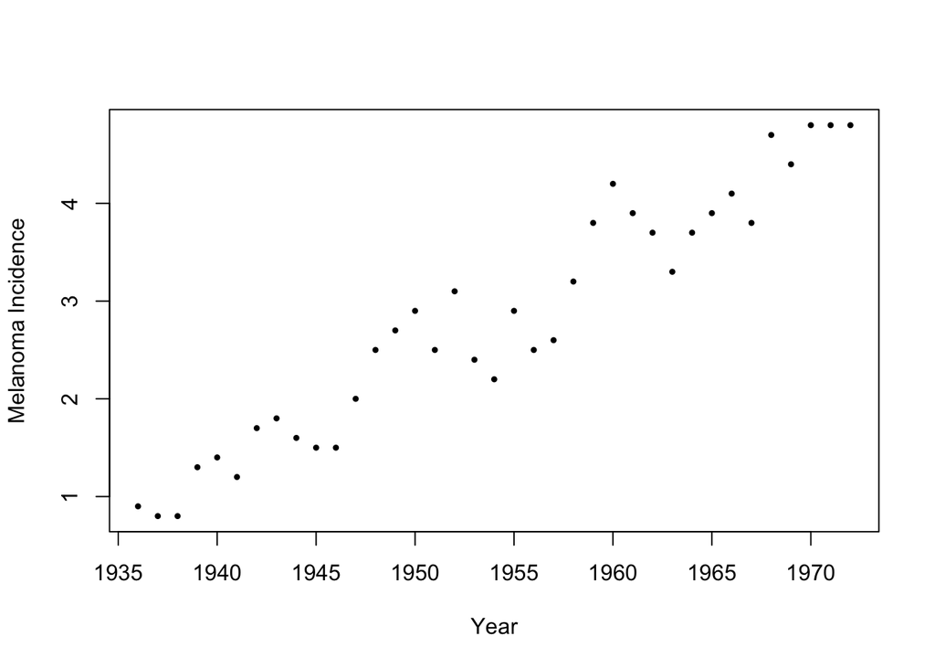

- How do we express a mean function for the following data of skin cancer incidences per 100,000 over a 37-year period?
- Is a simple linear regression sufficient: $Y = \beta_0 + \beta_1 x + \epsilon$?
- How about a polynomial model: $Y = \beta_0 + \beta_1 x + \beta_2 x^2 + \beta_3 x^3 + \epsilon$?
- How about a loess model (local polynomial weighted regression)?

## Parametric vs Nonparametric

Small span → very flexible (can overfit)  
Large span → smoother (can underfit)

**Advantages**

- Captures nonlinear relationships easily
- Does not assume any particular function form
- Works well for exploratory analysis and visualization

**Limitations**

- Computationally expensive for large datasets
- Does not easily provide a formula or model for prediction outside the observed range (no “global” model)
- Sensitive to outliers (though “robust LOWESS” versions exist)

## Choosing a Model

There is no single “best” model.

We compare using:

- Prediction error
- Interpretability
- Scientific plausibility
- Stability
- Scalability if you work with large data

## Takeaways

- The model is a useful abstraction for the purpose of analysis (confirmatory, prediction)  
  Models are tools, not truths
- There are often competing models for the same task and data set AND you want to compare several models!
- Randomness is a feature, not a bug
- Linear models are a foundation—not a destination
- Estimate the model parameters from data
- Assess the quality of the model based on the parameter estimates and various criteria (See Validation class)
- Statistical learning is about **tradeoffs**